# Supervised Learning_R4_Project2_Thera Bank

## Campaign for selling personal loans.

This case is about a bank (Thera Bank) which has a growing customer base. Majority of these customers are liability customers (depositors) with varying size of deposits. The number of customers who are also borrowers (asset customers) is quite small, and the bank is interested in expanding this base rapidly to bring in more loan business and in the process, earn more through the interest on loans. In particular, the management wants to explore ways of converting its liability customers to personal loan customers (while retaining them as depositors). A campaign that the bank ran last year for liability customers showed a healthy conversion rate of over 9% success. This has encouraged the retail marketing department to devise campaigns with better target marketing to increase the success ratio with minimal budget.

The department wants to build a model that will help them identify the potential customers who have higher probability of purchasing the loan. This will increase the success ratio while at the same time reduce the cost of the campaign.

The file Bank.xls contains data on 5000 customers. The data include customer demographic information (age, income, etc.), the customer's relationship with the bank (mortgage, securities account, etc.), and the customer response to the last personal loan campaign (Personal Loan). Among these 5000 customers, only 480 (= 9.6%) accepted the personal loan that was offered to them in the earlier campaign.

## Requirement / Steps

1. Read the column description and ensure you understand each attribute well
2. Study the data distribution in each attribute, share your findings. (5 points)
3. Get the target column distribution. Your comments
4. Split the data into training and test set in the ratio of 70:30 respectively
5. Use different classification models (Logistic, K-NN and Naïve Bayes) to predict the likelihood of a liability customer buying personal loans (15 points)
6. Print the confusion matrix for all the above models (5 points)
7. Give your reasoning on which is the best model in this case and why it performs better? (5 points)

Dataset:Bank_Personal_Loan_Modelling-1.csv

Column description: TheraBank_Column_Description.xlsx

## Data Description:

| Column Name | Description |
| --- | --- |
| ID | Customer ID |
| Age | Customer's age in completed years |
| Experience | #years of professional experience |
| Income | Annual income of the customer (Dollar 000) |
| ZIPCode | Home Address ZIP code. |
| Family | Family size of the customer |
| CCAvg | Avg. spending on credit cards per month (Dollar 000) |
| Education | Education Level. 1: Undergrad; 2: Graduate; 3: Advanced/Professional |
| Mortgage | Value of house mortgage if any. (Dollar 000) |
| Personal Loan | Did this customer accept the personal loan offered in the last campaign? |
| Securities Account | Does the customer have a securities account with the bank? |
| CD Account | Does the customer have a certificate of deposit (CD) account with the bank? |
| Online | Does the customer use internet banking facilities? |
| CreditCard | Does the customer use a credit card issued by UniversalBank? |

### TARGET COLUMN

- Personal Loan
  - It identifies if the customer responded to the last campaign

```python
%matplotlib inline
import numpy as np
import pandas as pd

import matplotlib.pyplot as plt
import seaborn as sns
```

```python
# Read the csv file containing the data
df_thera = pd.read_csv('Bank_Personal_Loan_Modelling-1.csv')
print(df_thera.shape)
df_thera.head()
```

```
(5000, 14)
```

|  | ID | Age | Experience | Income | ZIP Code | Family | CCAvg | Education | Mortgage | Personal Loan | Securities Account | CD Account | Online | CreditCard |
| --- | --- | --- | --- | --- | --- | --- | --- | --- | --- | --- | --- | --- | --- | --- |
| 0 | 1 | 25 | 1 | 49 | 91107 | 4 | 1.6 | 1 | 0 | 0 | 1 | 0 | 0 | 0 |
| 1 | 2 | 45 | 19 | 34 | 90089 | 3 | 1.5 | 1 | 0 | 0 | 1 | 0 | 0 | 0 |
| 2 | 3 | 39 | 15 | 11 | 94720 | 1 | 1.0 | 1 | 0 | 0 | 0 | 0 | 0 | 0 |
| 3 | 4 | 35 | 9 | 100 | 94112 | 1 | 2.7 | 2 | 0 | 0 | 0 | 0 | 0 | 0 |
| 4 | 5 | 35 | 8 | 45 | 91330 | 4 | 1.0 | 2 | 0 | 0 | 0 | 0 | 0 | 1 |

### Step 1

- Read the column description and ensure you understand each attribute well

```python
df_thera.describe().T
```

|  | count | mean | std | min | 25% | 50% | 75% | max |
| --- | --- | --- | --- | --- | --- | --- | --- | --- |
| ID | 5000.0 | 2500.500000 | 1443.520003 | 1.0 | 1250.75 | 2500.5 | 3750.25 | 5000.0 |
| Age | 5000.0 | 45.338400 | 11.463166 | 23.0 | 35.00 | 45.0 | 55.00 | 67.0 |
| Experience | 5000.0 | 20.104600 | 11.467954 | -3.0 | 10.00 | 20.0 | 30.00 | 43.0 |
| Income | 5000.0 | 73.774200 | 46.033729 | 8.0 | 39.00 | 64.0 | 98.00 | 224.0 |
| ZIP Code | 5000.0 | 93152.503000 | 2121.852197 | 9307.0 | 91911.00 | 93437.0 | 94608.00 | 96651.0 |
| Family | 5000.0 | 2.396400 | 1.147663 | 1.0 | 1.00 | 2.0 | 3.00 | 4.0 |
| CCAvg | 5000.0 | 1.937938 | 1.747659 | 0.0 | 0.70 | 1.5 | 2.50 | 10.0 |
| Education | 5000.0 | 1.881000 | 0.839869 | 1.0 | 1.00 | 2.0 | 3.00 | 3.0 |
| Mortgage | 5000.0 | 56.498800 | 101.713802 | 0.0 | 0.00 | 0.0 | 101.00 | 635.0 |
| Personal Loan | 5000.0 | 0.096000 | 0.294621 | 0.0 | 0.00 | 0.0 | 0.00 | 1.0 |
| Securities Account | 5000.0 | 0.104400 | 0.305809 | 0.0 | 0.00 | 0.0 | 0.00 | 1.0 |
| CD Account | 5000.0 | 0.060400 | 0.238250 | 0.0 | 0.00 | 0.0 | 0.00 | 1.0 |
| Online | 5000.0 | 0.596800 | 0.490589 | 0.0 | 0.00 | 1.0 | 1.00 | 1.0 |
| CreditCard | 5000.0 | 0.294000 | 0.455637 | 0.0 | 0.00 | 0.0 | 1.00 | 1.0 |

### Step 2

- Study the data distribution in each attribute, share your findings. (5 points)

```python
df_thera.nunique()
```

```
ID                    5000
Age                     45
Experience              47
Income                 162
ZIP Code               467
Family                   4
CCAvg                  108
Education                3
Mortgage               347
Personal Loan            2
Securities Account       2
CD Account               2
Online                   2
CreditCard               2
dtype: int64
```

**Findings from describe() and nunique()**  
- ID...can be dropped  
- Experience...need to remove negatives...and do outlier treatment  
- Income...do outlier treatment  
- Zipcode...classification data...too many unique values...find a way to reduce the unique values (maybe convert to state or town), else drop  
- Family...ordinal data  
- CCAvg...do outlier treatment  
- Education...ordinal data  
- Mortgage...check in more detail  
- Personal Loan...classification data...TARGET COLUMN  
- Securities Account...classification data  
- CD Account...classification data  
- Online...classification data  
- CreditCard...classification data

```python
df_thera.info()
```

```
<class 'pandas.core.frame.DataFrame'>
RangeIndex: 5000 entries, 0 to 4999
Data columns (total 14 columns):
ID                    5000 non-null int64
Age                   5000 non-null int64
Experience            5000 non-null int64
Income                5000 non-null int64
ZIP Code              5000 non-null int64
Family                5000 non-null int64
CCAvg                 5000 non-null float64
Education             5000 non-null int64
Mortgage              5000 non-null int64
Personal Loan         5000 non-null int64
Securities Account    5000 non-null int64
CD Account            5000 non-null int64
Online                5000 non-null int64
CreditCard            5000 non-null int64
dtypes: float64(1), int64(13)
memory usage: 547.0 KB
```

### Findings from info()

- No missing values
- All columns have numeric values

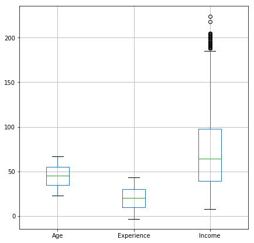

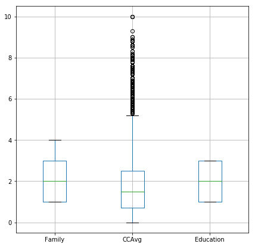

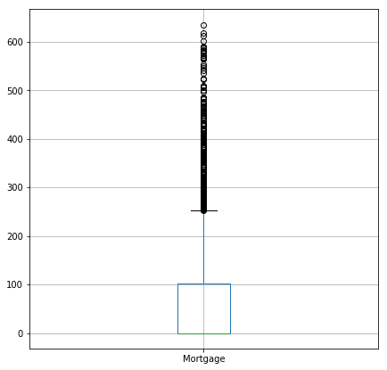

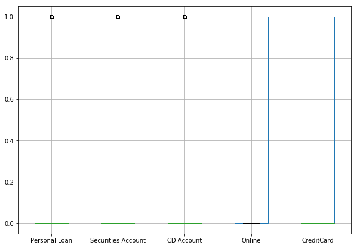

```python
# BOX PLOT

plt.figure(figsize=[7,7])
# pd.options.display.mpl_style = 'default' # Change the style of drawing graphs in matplotlib to default
df_thera[['Age', 'Experience', 'Income']].boxplot()

# No need to do boxplot of ZIP Code

plt.figure(figsize=[7,7])
df_thera[['Family', 'CCAvg', 'Education']].boxplot()

plt.figure(figsize=[7,7])
df_thera[['Mortgage']].boxplot()

plt.figure(figsize=[10,7])
df_thera[['Personal Loan', 'Securities Account', 'CD Account', 'Online', 'CreditCard']].boxplot()
```

**Findings from boxplot()**  
- Class imbalanced features  
a) Personal Loan  
b) Securities Account  
c) CD Account  
- Outliers in following features  
a) Income  
b) CCAvg  
c) Mortgage  
- Relatively normal distribution  
a) Age  
b) Experience  
c) Education

```
array([[<matplotlib.axes._subplots.AxesSubplot object at 0x0000019F3F5E9240>,
      dtype=object)
```

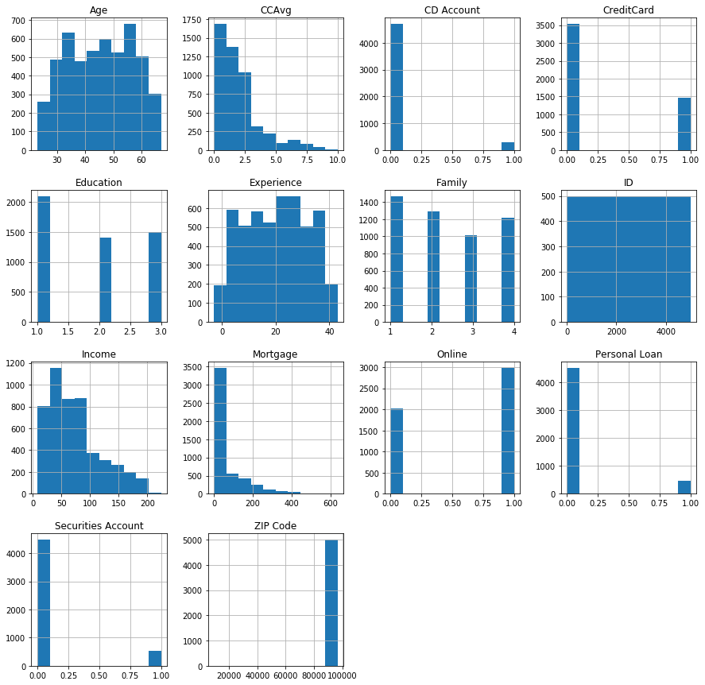

```python
df_thera.hist(figsize=[15,15])
```

### Step 3

- Get the target column distribution. Your comments

```
Data points with personal loan value of 0:  (4520, 14)
```

```
array([[<matplotlib.axes._subplots.AxesSubplot object at 0x0000019F40118F98>,
      dtype=object)
```

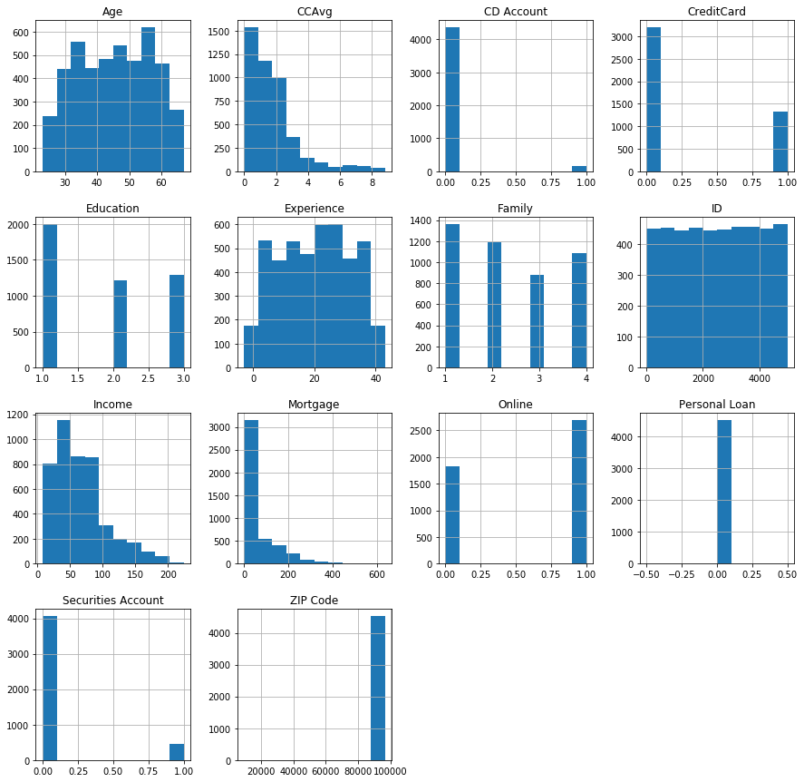

```python
# Draw histogram for data points which did not take Personal Loan (= 0)
temp = df_thera[df_thera["Personal Loan"] == 0]
print("Data points with personal loan value of 0: ", temp.shape)

temp.hist(figsize=[15,15])
```

```
Data points with personal loan value of 1:  (480, 14)
```

```
array([[<matplotlib.axes._subplots.AxesSubplot object at 0x0000019F3F9386D8>,
      dtype=object)
```

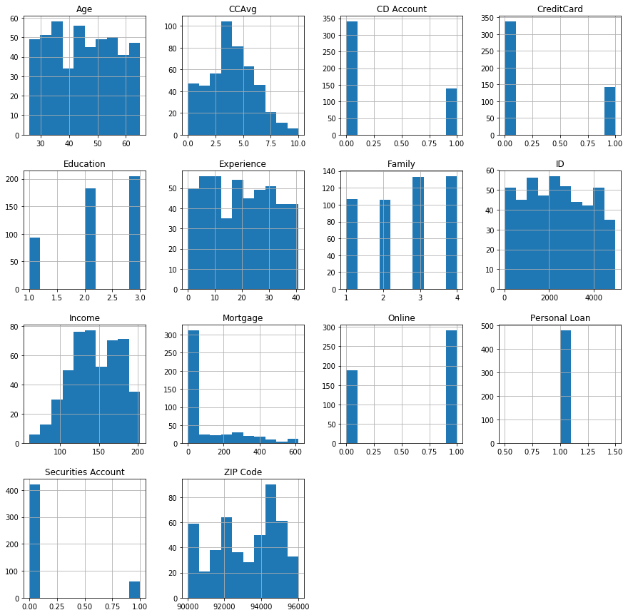

```python
temp = df_thera[df_thera["Personal Loan"] == 1]
print("Data points with personal loan value of 1: ", temp.shape)

# Draw histogram for data points which took personal loan (= 1)
#df_thera[df_thera["Personal Loan"] == 1].hist(figsize=[15,15])
temp.hist(figsize=[15,15])
```

```
Personal Loan
0    AxesSubplot(0.125,0.125;0.775x0.755)
1    AxesSubplot(0.125,0.125;0.775x0.755)
Name: Age, dtype: object
```

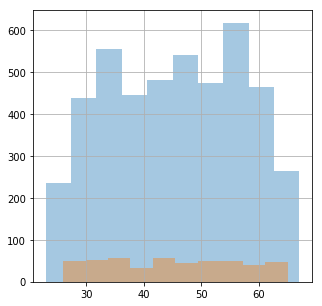

```python
df_thera.groupby("Personal Loan").Age.hist(alpha=0.4, figsize=[5,5])
```

```
Personal Loan
0    AxesSubplot(0.125,0.125;0.775x0.755)
1    AxesSubplot(0.125,0.125;0.775x0.755)
Name: Experience, dtype: object
```

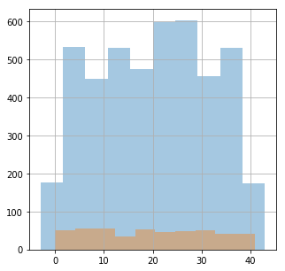

```python
df_thera.groupby("Personal Loan").Experience.hist(alpha=0.4, figsize=[5,5])
```

```
Personal Loan
0    AxesSubplot(0.125,0.125;0.775x0.755)
1    AxesSubplot(0.125,0.125;0.775x0.755)
Name: Income, dtype: object
```

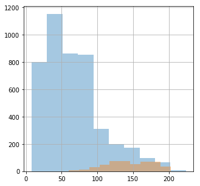

```python
df_thera.groupby("Personal Loan").Income.hist(alpha=0.4, figsize=[5,5])
```

```python
# No need to draw comparision to ZIP Code
#df_thera.groupby("Personal Loan")["ZIP Code"].hist(alpha=0.4, figsize=[5,5])
```

```
Personal Loan
0    AxesSubplot(0.125,0.125;0.775x0.755)
1    AxesSubplot(0.125,0.125;0.775x0.755)
Name: Family, dtype: object
```

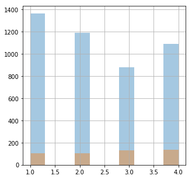

```python
df_thera.groupby("Personal Loan").Family.hist(alpha=0.4, figsize=[5,5])
```

```
Personal Loan
0    AxesSubplot(0.125,0.125;0.775x0.755)
1    AxesSubplot(0.125,0.125;0.775x0.755)
Name: CCAvg, dtype: object
```

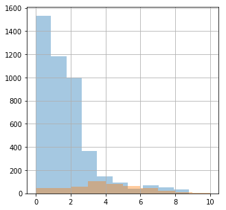

```python
df_thera.groupby("Personal Loan").CCAvg.hist(alpha=0.4, figsize=[5,5])
```

```
Personal Loan
0    AxesSubplot(0.125,0.125;0.775x0.755)
1    AxesSubplot(0.125,0.125;0.775x0.755)
Name: Education, dtype: object
```

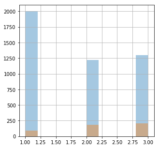

```python
df_thera.groupby("Personal Loan").Education.hist(alpha=0.4, figsize=[5,5])
```

```
Personal Loan
0    AxesSubplot(0.125,0.125;0.775x0.755)
1    AxesSubplot(0.125,0.125;0.775x0.755)
Name: Mortgage, dtype: object
```

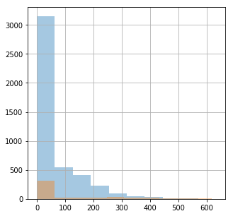

```python
df_thera.groupby("Personal Loan").Mortgage.hist(alpha=0.4, figsize=[5,5])
```

```
Personal Loan
0    AxesSubplot(0.125,0.125;0.775x0.755)
1    AxesSubplot(0.125,0.125;0.775x0.755)
Name: Securities Account, dtype: object
```

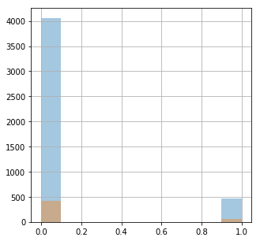

```python
df_thera.groupby("Personal Loan")["Securities Account"].hist(alpha=0.4, figsize=[5,5])
```

```
Personal Loan
0    AxesSubplot(0.125,0.125;0.775x0.755)
1    AxesSubplot(0.125,0.125;0.775x0.755)
Name: CD Account, dtype: object
```

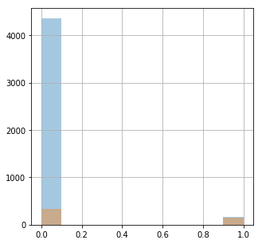

```python
df_thera.groupby("Personal Loan")["CD Account"].hist(alpha=0.4, figsize=[5,5])
```

```
Check histogram of Personal Loan at (CD Account = 1)
```

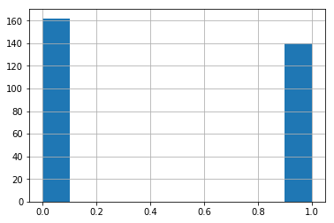

```python
print("Check histogram of Personal Loan at (CD Account = 1)")
temp = df_thera[df_thera["CD Account"] == 1]
temp["Personal Loan"].hist()
```

```
Personal Loan
0    AxesSubplot(0.125,0.125;0.775x0.755)
1    AxesSubplot(0.125,0.125;0.775x0.755)
Name: Online, dtype: object
```

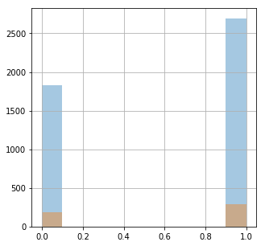

```python
df_thera.groupby("Personal Loan").Online.hist(alpha=0.4, figsize=[5,5])
```

```
Personal Loan
0    AxesSubplot(0.125,0.125;0.775x0.755)
1    AxesSubplot(0.125,0.125;0.775x0.755)
Name: CreditCard, dtype: object
```

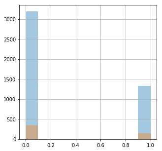

```python
df_thera.groupby("Personal Loan").CreditCard.hist(alpha=0.4, figsize=[5,5])
```

```python
corr_df = df_thera.corr()
corr_df
```

|  | ID | Age | Experience | Income | ZIP Code | Family | CCAvg | Education | Mortgage | Personal Loan | Securities Account | CD Account | Online | CreditCard |
| --- | --- | --- | --- | --- | --- | --- | --- | --- | --- | --- | --- | --- | --- | --- |
| ID | 1.000000 | -0.008473 | -0.008326 | -0.017695 | 0.013432 | -0.016797 | -0.024675 | 0.021463 | -0.013920 | -0.024801 | -0.016972 | -0.006909 | -0.002528 | 0.017028 |
| Age | -0.008473 | 1.000000 | 0.994215 | -0.055269 | -0.029216 | -0.046418 | -0.052012 | 0.041334 | -0.012539 | -0.007726 | -0.000436 | 0.008043 | 0.013702 | 0.007681 |
| Experience | -0.008326 | 0.994215 | 1.000000 | -0.046574 | -0.028626 | -0.052563 | -0.050077 | 0.013152 | -0.010582 | -0.007413 | -0.001232 | 0.010353 | 0.013898 | 0.008967 |
| Income | -0.017695 | -0.055269 | -0.046574 | 1.000000 | -0.016410 | -0.157501 | 0.645984 | -0.187524 | 0.206806 | 0.502462 | -0.002616 | 0.169738 | 0.014206 | -0.002385 |
| ZIP Code | 0.013432 | -0.029216 | -0.028626 | -0.016410 | 1.000000 | 0.011778 | -0.004061 | -0.017377 | 0.007383 | 0.000107 | 0.004704 | 0.019972 | 0.016990 | 0.007691 |
| Family | -0.016797 | -0.046418 | -0.052563 | -0.157501 | 0.011778 | 1.000000 | -0.109275 | 0.064929 | -0.020445 | 0.061367 | 0.019994 | 0.014110 | 0.010354 | 0.011588 |
| CCAvg | -0.024675 | -0.052012 | -0.050077 | 0.645984 | -0.004061 | -0.109275 | 1.000000 | -0.136124 | 0.109905 | 0.366889 | 0.015086 | 0.136534 | -0.003611 | -0.006689 |
| Education | 0.021463 | 0.041334 | 0.013152 | -0.187524 | -0.017377 | 0.064929 | -0.136124 | 1.000000 | -0.033327 | 0.136722 | -0.010812 | 0.013934 | -0.015004 | -0.011014 |
| Mortgage | -0.013920 | -0.012539 | -0.010582 | 0.206806 | 0.007383 | -0.020445 | 0.109905 | -0.033327 | 1.000000 | 0.142095 | -0.005411 | 0.089311 | -0.005995 | -0.007231 |
| Personal Loan | -0.024801 | -0.007726 | -0.007413 | 0.502462 | 0.000107 | 0.061367 | 0.366889 | 0.136722 | 0.142095 | 1.000000 | 0.021954 | 0.316355 | 0.006278 | 0.002802 |
| Securities Account | -0.016972 | -0.000436 | -0.001232 | -0.002616 | 0.004704 | 0.019994 | 0.015086 | -0.010812 | -0.005411 | 0.021954 | 1.000000 | 0.317034 | 0.012627 | -0.015028 |
| CD Account | -0.006909 | 0.008043 | 0.010353 | 0.169738 | 0.019972 | 0.014110 | 0.136534 | 0.013934 | 0.089311 | 0.316355 | 0.317034 | 1.000000 | 0.175880 | 0.278644 |
| Online | -0.002528 | 0.013702 | 0.013898 | 0.014206 | 0.016990 | 0.010354 | -0.003611 | -0.015004 | -0.005995 | 0.006278 | 0.012627 | 0.175880 | 1.000000 | 0.004210 |
| CreditCard | 0.017028 | 0.007681 | 0.008967 | -0.002385 | 0.007691 | 0.011588 | -0.006689 | -0.011014 | -0.007231 | 0.002802 | -0.015028 | 0.278644 | 0.004210 | 1.000000 |

```python
def correlationThresholdCutter(corr_data, threshold, targetLabel):
    #corr_threshold = 0.70;
    count = 0;
    if targetLabel == "":
        targetLabel == ""

    corr_threshold = threshold**2   # Square to get positive value for negative values as well

    for i in range(0, len(corr_data)):
        #for j in range(0, len(x_cor)):

        # X and Y axis columns are same. Limiting j to (i + 1) will only compare once between 2 columns.
        # Without this same columns will be compared twice.
        for j in range(0, i + 1):
            entry = corr_data.iloc[i, j]
            entry_squared = entry**2
            if(entry_squared >= corr_threshold):
                x_axis_col_lab = corr_data.index.values[i]
                y_axis_col_lab = corr_data.index.values[j]
                if x_axis_col_lab != y_axis_col_lab:
                    if(x_axis_col_lab == targetLabel):
                        print("***", x_axis_col_lab, "*** corr with ", y_axis_col_lab, " is: ", entry)
                    elif y_axis_col_lab == targetLabel:
                        print(x_axis_col_lab, " corr with ***", y_axis_col_lab, "*** is: ", entry)
                    else:
                        print(x_axis_col_lab, " corr with ", y_axis_col_lab, " is: ", entry)
                    count = count + 1
    return
```

```python
correlationThresholdCutter(corr_df, 0.30, "Personal Loan")
```

```
Experience  corr with  Age  is:  0.9942148569683271
CCAvg  corr with  Income  is:  0.645983669624964
*** Personal Loan *** corr with  Income  is:  0.5024622924949513
*** Personal Loan *** corr with  CCAvg  is:  0.36688873553709456
CD Account  corr with *** Personal Loan *** is:  0.3163548294144298
CD Account  corr with  Securities Account  is:  0.31703441568066
```

```python
# For the classification features above, is personal loan balanced among all classes

# In other words the count of data points with personal loan compared to without personal loan is how similar
# for the different values of the feature
```

```python
#from pandas.plotting import scatter_matrix

#scatter_matrix(df_thera, alpha = 0.2, figsize=[10,10], diagonal='kde')
#sns.pairplot(df_thera, diag_kind='kde')
```

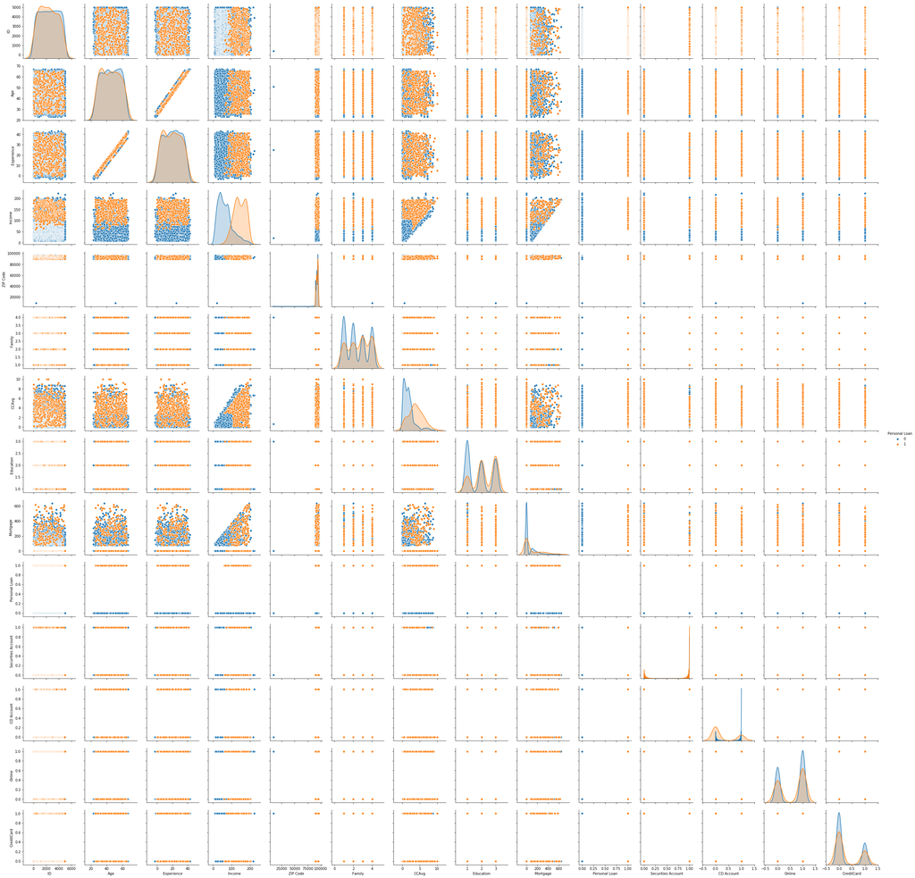

```python
sns.pairplot(df_thera, diag_kind='kde', hue="Personal Loan")
```

```python
# plt.scatter(df_thera['Personal Loan'], df_thera['Income'])
# plt.xlabel("Personal Loan")
# plt.ylabel("Income")
# plt.show()

# plt.scatter(df_thera['Personal Loan'], df_thera['Family'])
# plt.xlabel("Personal Loan")
# plt.ylabel("Family")
# plt.show()

# plt.scatter(df_thera['Personal Loan'], df_thera['CCAvg'])
# plt.xlabel("Personal Loan")
# plt.ylabel("CCAvg")
# plt.show()

# plt.scatter(df_thera['Personal Loan'], df_thera['Education'])
# plt.xlabel("Personal Loan")
# plt.ylabel("Education")
# plt.show()

# plt.scatter(df_thera['Personal Loan'], df_thera['Mortgage'])
# plt.xlabel("Personal Loan")
# plt.ylabel("Mortgage")
# plt.show()

# plt.scatter(df_thera['Personal Loan'], df_thera['Securities Account'])
# plt.xlabel("Personal Loan")
# plt.ylabel("Securities Account")
# plt.show()
```

```python
# plt.scatter(df_thera['Personal Loan'], df_thera['CD Account'])
# plt.xlabel("Personal Loan")
# plt.ylabel("CD Account")
# plt.show()

# plt.scatter(df_thera['Personal Loan'], df_thera['Online'])
# plt.xlabel("Personal Loan")
# plt.ylabel("Online")
# plt.show()

# plt.scatter(df_thera['Personal Loan'], df_thera['CreditCard'])
# plt.xlabel("Personal Loan")
# plt.ylabel("CreditCard")
# plt.show()
```

**Findings on target (Personal Loan) from correlations matrix (at threshold value of 0.3)**

### Step 4

- Split the data into training and test set in the ratio of 70:30 respectively

## Before dividing data into training and test set prepare data

**Prepare data for modelling using following**

```
- Reread the file (in case some modification is done by previous EDA steps)
- Remove unnecessary features
- Remove/replace negatives values in certain columns (here Experience)
- Remove outliers
- Apply dummies and label encoding where necessary
```

```python
df_thera = pd.read_csv('Bank_Personal_Loan_Modelling-1.csv')

# Drop ID and ZIP Code
df_thera.drop(["ID", "ZIP Code"], inplace=True, axis=1)
df_thera.head()
```

|  | Age | Experience | Income | Family | CCAvg | Education | Mortgage | Personal Loan | Securities Account | CD Account | Online | CreditCard |
| --- | --- | --- | --- | --- | --- | --- | --- | --- | --- | --- | --- | --- |
| 0 | 25 | 1 | 49 | 4 | 1.6 | 1 | 0 | 0 | 1 | 0 | 0 | 0 |
| 1 | 45 | 19 | 34 | 3 | 1.5 | 1 | 0 | 0 | 1 | 0 | 0 | 0 |
| 2 | 39 | 15 | 11 | 1 | 1.0 | 1 | 0 | 0 | 0 | 0 | 0 | 0 |
| 3 | 35 | 9 | 100 | 1 | 2.7 | 2 | 0 | 0 | 0 | 0 | 0 | 0 |
| 4 | 35 | 8 | 45 | 4 | 1.0 | 2 | 0 | 0 | 0 | 0 | 0 | 1 |

```python
# Define function to apply dummies and label encoding
def apply_d_l(inputX):
    # apply dummies
    out = pd.get_dummies(inputX, columns=["Securities Account"])
    out = pd.get_dummies(out, columns=["CD Account"])
    out = pd.get_dummies(out, columns=["Online"])
    out = pd.get_dummies(out, columns=["CreditCard"])

    # apply label encoding
    #out['Family'] = out['Family'].replace({"???": 0, '???': 1, '???': 2, '???': 3})

    return out

### *** ###

# Method to identify and replace outliers with min or max
def removeOutliers(x, column_name):
    a = np.array(x)
    q3 = np.percentile(a, 75)
    q1 = np.percentile(a, 25)
    iqr = q3 - q1
    quartileSet = [q1 - 1.5*iqr, q3 + 1.5*iqr]
    #mean = x.mean()
    minimum = x.min()
    maximum = x.max()
    resultList = []
    for i in range(len(a)):
        #if a[i] <= quartileSet[0] or a[i] >= quartileSet[1]:
        if a[i] <= quartileSet[0] or a[i] > quartileSet[1]:
            resultList.append(a[i])
            if a[i] < quartileSet[0]:
                a[i] = minimum
            elif a[i] > quartileSet[1]:
                a[i] = maximum
    print("---***---")
    print("COLUMN NAME: ", column_name)
    print("Quartile Set: ", quartileSet)
    #print("Mean: ", mean)
    print("Min: ", minimum)
    print("Max: ", maximum)
    print("Number of outliers: ", len(resultList))
    print("Outliers: ", resultList)
    # x = pd.Series(a)
    return pd.Series(a)

### *** ###

# Method to replace negative values with median
def replaceNegatives(x, column_name):
    a = np.array(x)
    median = x.median()
    resultList = []
    for i in range(len(a)):
        if a[i] < 0:
            resultList.append(a[i])
            a[i] = median
    print("---***---")
    print("COLUMN NAME: ", column_name)
    print("Median: ", median)
    print("Number of negatives: ", len(resultList))
    print("Negatives: ", resultList)
    x = pd.Series(a)
    return pd.Series(a)
```

```python
# Remove negative value from Experience
df_thera['Experience'] = replaceNegatives(df_thera['Experience'], 'Experience')

# Remove outliers
df_thera['Experience'] = removeOutliers(df_thera['Experience'], 'Experience')
df_thera['Income'] = removeOutliers(df_thera['Income'], 'Income')
df_thera['CCAvg'] = removeOutliers(df_thera['CCAvg'], 'CCAvg')

# Apply dummies and label encoding
df_thera = apply_d_l(df_thera)

df_thera.head()
```

```
---***---
COLUMN NAME:  Experience
Median:  20.0
Number of negatives:  52
Negatives:  [-1, -1, -2, -2, -1, -1, -1, -1, -1, -2, -1, -1, -1, -2, -2, -1, -1, -1, -1, -1, -1, -1, -2, -1, -3, -2, -1, -2, -2, -1, -1, -2, -1, -1, -1, -1, -1, -1, -3, -2, -1, -2, -1, -1, -1, -2, -3, -2, -2, -3, -1, -1]
---***---
COLUMN NAME:  Experience
Quartile Set:  [-17.5, 58.5]
Min:  0
Max:  43
Number of outliers:  0
Outliers:  []
---***---
COLUMN NAME:  Income
Quartile Set:  [-49.5, 186.5]
Min:  8
Max:  224
Number of outliers:  96
Outliers:  [193, 194, 190, 188, 195, 191, 200, 205, 204, 195, 192, 194, 202, 195, 200, 193, 192, 195, 191, 188, 191, 190, 190, 194, 195, 192, 190, 195, 191, 192, 195, 192, 193, 190, 198, 201, 200, 188, 192, 190, 194, 201, 191, 191, 188, 203, 189, 193, 190, 204, 198, 201, 201, 191, 191, 195, 190, 188…
---***---
COLUMN NAME:  CCAvg
Quartile Set:  [-2.0, 5.2]
Min:  0.0
Max:  10.0
Number of outliers:  324
Outliers:  [8.9, 8.1, 5.7, 8.0, 5.7, 5.6, 7.2, 7.4, 7.5, 6.5, 6.5, 7.8, 7.9, 6.8, 7.4, 7.5, 7.9, 6.2, 5.5, 6.9, 7.5, 7.3, 6.1, 6.33, 6.6, 5.3, 7.5, 6.8, 7.0, 6.6, 6.3, 7.5, 5.7, 8.3, 5.5, 6.9, 6.1, 6.0, 8.0, 6.8, 6.33, 7.8, 7.2, 6.5, 6.8, 6.0, 7.2, 8.6, 6.9, 6.1, 7.8, 6.0, 7.6, 7.4, 6.1, 7.0, 8.1, 6…
```

|  | Age | Experience | Income | Family | CCAvg | Education | Mortgage | Personal Loan | Securities Account_0 | Securities Account_1 | CD Account_0 | CD Account_1 | Online_0 | Online_1 | CreditCard_0 | CreditCard_1 |
| --- | --- | --- | --- | --- | --- | --- | --- | --- | --- | --- | --- | --- | --- | --- | --- | --- |
| 0 | 25 | 1 | 49 | 4 | 1.6 | 1 | 0 | 0 | 0 | 1 | 1 | 0 | 1 | 0 | 1 | 0 |
| 1 | 45 | 19 | 34 | 3 | 1.5 | 1 | 0 | 0 | 0 | 1 | 1 | 0 | 1 | 0 | 1 | 0 |
| 2 | 39 | 15 | 11 | 1 | 1.0 | 1 | 0 | 0 | 1 | 0 | 1 | 0 | 1 | 0 | 1 | 0 |
| 3 | 35 | 9 | 100 | 1 | 2.7 | 2 | 0 | 0 | 1 | 0 | 1 | 0 | 1 | 0 | 1 | 0 |
| 4 | 35 | 8 | 45 | 4 | 1.0 | 2 | 0 | 0 | 1 | 0 | 1 | 0 | 1 | 0 | 0 | 1 |

```python
df_thera.describe().T
```

|  | count | mean | std | min | 25% | 50% | 75% | max |
| --- | --- | --- | --- | --- | --- | --- | --- | --- |
| Age | 5000.0 | 45.338400 | 11.463166 | 23.0 | 35.0 | 45.0 | 55.0 | 67.0 |
| Experience | 5000.0 | 20.327600 | 11.253035 | 0.0 | 11.0 | 20.0 | 30.0 | 43.0 |
| Income | 5000.0 | 74.337400 | 47.653052 | 8.0 | 39.0 | 64.0 | 98.0 | 224.0 |
| Family | 5000.0 | 2.396400 | 1.147663 | 1.0 | 1.0 | 2.0 | 3.0 | 4.0 |
| CCAvg | 5000.0 | 2.142378 | 2.366738 | 0.0 | 0.7 | 1.5 | 2.5 | 10.0 |
| Education | 5000.0 | 1.881000 | 0.839869 | 1.0 | 1.0 | 2.0 | 3.0 | 3.0 |
| Mortgage | 5000.0 | 56.498800 | 101.713802 | 0.0 | 0.0 | 0.0 | 101.0 | 635.0 |
| Personal Loan | 5000.0 | 0.096000 | 0.294621 | 0.0 | 0.0 | 0.0 | 0.0 | 1.0 |
| Securities Account_0 | 5000.0 | 0.895600 | 0.305809 | 0.0 | 1.0 | 1.0 | 1.0 | 1.0 |
| Securities Account_1 | 5000.0 | 0.104400 | 0.305809 | 0.0 | 0.0 | 0.0 | 0.0 | 1.0 |
| CD Account_0 | 5000.0 | 0.939600 | 0.238250 | 0.0 | 1.0 | 1.0 | 1.0 | 1.0 |
| CD Account_1 | 5000.0 | 0.060400 | 0.238250 | 0.0 | 0.0 | 0.0 | 0.0 | 1.0 |
| Online_0 | 5000.0 | 0.403200 | 0.490589 | 0.0 | 0.0 | 0.0 | 1.0 | 1.0 |
| Online_1 | 5000.0 | 0.596800 | 0.490589 | 0.0 | 0.0 | 1.0 | 1.0 | 1.0 |
| CreditCard_0 | 5000.0 | 0.706000 | 0.455637 | 0.0 | 0.0 | 1.0 | 1.0 | 1.0 |
| CreditCard_1 | 5000.0 | 0.294000 | 0.455637 | 0.0 | 0.0 | 0.0 | 1.0 | 1.0 |

### Divide data into training and test set

```python
from sklearn.model_selection import train_test_split

X = df_thera.drop("Personal Loan", axis=1)
Y = df_thera["Personal Loan"]

X_train, X_test, Y_train, Y_test = train_test_split(X, Y, test_size=0.30)
```

### Step 5

- Use different classification models (Logistic, K-NN and Naïve Bayes) to predict the likelihood of a liability customer buying personal loans (15 points)

### LOGISTIC

```python
from sklearn.linear_model import LogisticRegression

logistic_model = LogisticRegression(max_iter=1000)
logistic_model.fit(X_train, Y_train)
```

```
LogisticRegression(C=1.0, class_weight=None, dual=False, fit_intercept=True,
          intercept_scaling=1, max_iter=1000, multi_class='warn',
          n_jobs=None, penalty='l2', random_state=None, solver='warn',
          tol=0.0001, verbose=0, warm_start=False)
```

### K-NN

```
Min error observed in the provided range of K values is:  0.08866666666666667
Optimum K value in the provided range is:  2
```

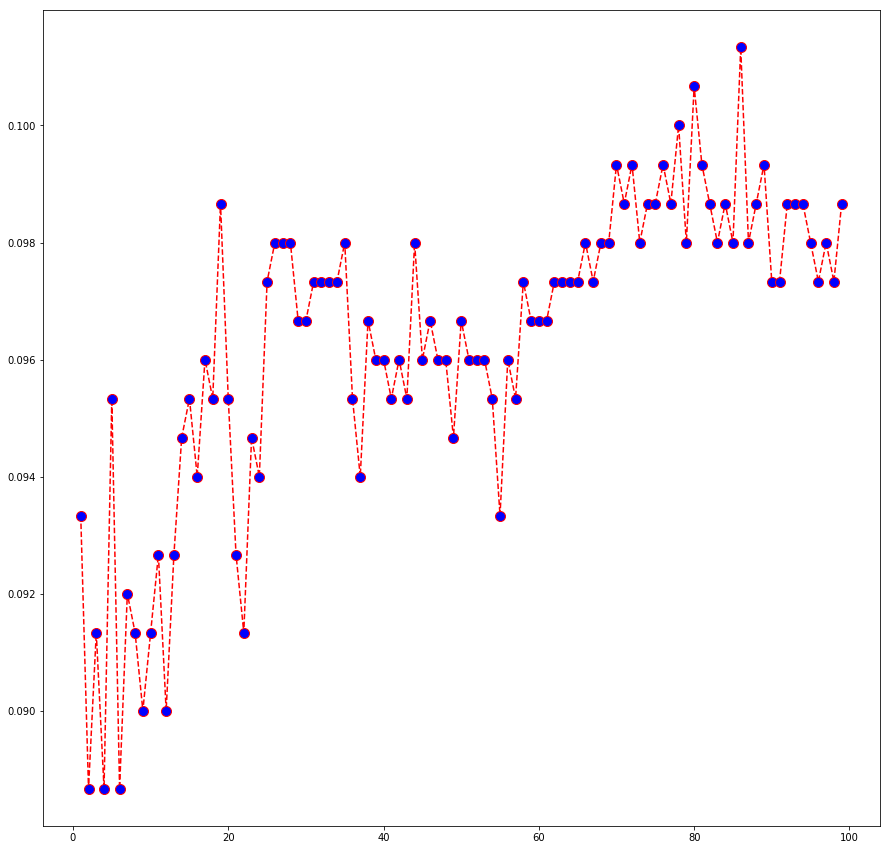

```
KNeighborsClassifier(algorithm='auto', leaf_size=30, metric='minkowski',
           metric_params=None, n_jobs=None, n_neighbors=2, p=2,
           weights='uniform')
```

```python
from sklearn.neighbors import KNeighborsClassifier

testedMaxK = 100
error = []
minError = 1
kOptimum = 0

# Get optimum value of K
for i in range(1, testedMaxK):
    knn = KNeighborsClassifier(n_neighbors=i)
    knn.fit(X_train, Y_train)
    pred = knn.predict(X_test)
    err = np.mean(pred != np.asarray(Y_test))
    error.append(err)
    if err < minError:
        minError = err
        kOptimum = i


print("Min error observed in the provided range of K values is: ", minError)
print("Optimum K value in the provided range is: ", kOptimum)


# Plot error against the K value
plt.figure(figsize=[15,15])
plt.plot(range(1,testedMaxK), error, color="red", linestyle="dashed",
         marker="o", markerfacecolor="blue", markersize=10)
plt.xlabel = "K Value"
plt.ylabel = "Mean error"
plt.show()


# Create the final K-NN model
knn_model = KNeighborsClassifier(kOptimum)
knn_model.fit(X_train, Y_train)
```

### NAIVE BAYES

```python
from sklearn.naive_bayes import GaussianNB

naiveBayes_model = GaussianNB()
naiveBayes_model.fit(X_train, Y_train)
```

```
GaussianNB(priors=None, var_smoothing=1e-09)
```

**Now, use each model to predict and check the accuracy**

```python
logistic_pred = logistic_model.predict(X_test)
knn_pred = knn_model.predict(X_test)
naiveBayes_pred = naiveBayes_model.predict(X_test)

from sklearn.metrics import accuracy_score

logistic_accuracy = accuracy_score(Y_test, logistic_pred)
knn_accuracy = accuracy_score(Y_test, knn_pred)
naiveBayes_accuracy = accuracy_score(Y_test, naiveBayes_pred)

print("Logistic model accuracy score: ", logistic_accuracy)
print("K-NN model accuracy score: ", knn_accuracy)
print("Naive Bayes model accuracy score: ", naiveBayes_accuracy)
```

```
Logistic model accuracy score:  0.946
K-NN model accuracy score:  0.9113333333333333
Naive Bayes model accuracy score:  0.8853333333333333
```

### Step 6

- Print the confusion matrix for all the above models (5 points)

```python
from sklearn.metrics import confusion_matrix

logistic_confusionMatrix = confusion_matrix(Y_test, logistic_pred)
knn_confusionMatrix = confusion_matrix(Y_test, knn_pred)
naiveBayes_confusionMatrix = confusion_matrix(Y_test, naiveBayes_pred)

print("Logistic model confusion matrix: \n", logistic_confusionMatrix)
print("***")
print("K-NN model confusion matrix: \n", knn_confusionMatrix)
print("***")
print("Naive Bayes model confusion matrix: \n", naiveBayes_confusionMatrix)
```

```
Logistic model confusion matrix:
 [[1329   24]
 [  57   90]]
***
K-NN model confusion matrix:
 [[1337   16]
 [ 117   30]]
***
Naive Bayes model confusion matrix:
 [[1238  115]
 [  57   90]]
```

### Step 7

- Give your reasoning on which is the best model in this case and why it performs better? (5 points)